# Practical Machine Learning Project

Meet Bhavesh Shah

24/08/2020

## Background

Using devices such as Jawbone Up, Nike FuelBand, and Fitbit it is now possible to collect a large amount of data about personal activity relatively inexpensively. These type of devices are part of the quantified self movement – a group of enthusiasts who take measurements about themselves regularly to improve their health, to find patterns in their behavior, or because they are tech geeks. One thing that people regularly do is quantify how much of a particular activity they do, but they rarely quantify how well they do it. In this project, your goal will be to use data from accelerometers on the belt, forearm, arm, and dumbell of 6 participants. They were asked to perform barbell lifts correctly and incorrectly in 5 different ways.

## Loading Libraries

```r
library(caret)
```

```r
library(ggplot2)
library(rpart)
library(yardstick)
library(randomForest)
```

## Loading the dataset

```r
training <- read.csv("pml-training.csv")
```

Understanding the dataset

```r
training[1,]
```

```
##   X user_name raw_timestamp_part_1 raw_timestamp_part_2   cvtd_timestamp
## 1 1  carlitos           1323084231               788290 05/12/2011 11:23
##   new_window num_window roll_belt pitch_belt yaw_belt total_accel_belt
## 1         no         11      1.41       8.07    -94.4                3
##   kurtosis_roll_belt kurtosis_picth_belt kurtosis_yaw_belt skewness_roll_belt
## 1
##   skewness_roll_belt.1 skewness_yaw_belt max_roll_belt max_picth_belt
## 1                                                   NA             NA
##   max_yaw_belt min_roll_belt min_pitch_belt min_yaw_belt amplitude_roll_belt
## 1                         NA             NA                               NA
##   amplitude_pitch_belt amplitude_yaw_belt var_total_accel_belt avg_roll_belt
## 1                   NA                                      NA            NA
##   stddev_roll_belt var_roll_belt avg_pitch_belt stddev_pitch_belt
## 1               NA            NA             NA                NA
##   var_pitch_belt avg_yaw_belt stddev_yaw_belt var_yaw_belt gyros_belt_x
## 1             NA           NA              NA           NA            0
##   gyros_belt_y gyros_belt_z accel_belt_x accel_belt_y accel_belt_z
## 1            0        -0.02          -21            4           22
##   magnet_belt_x magnet_belt_y magnet_belt_z roll_arm pitch_arm yaw_arm
## 1            -3           599          -313     -128      22.5    -161
##   total_accel_arm var_accel_arm avg_roll_arm stddev_roll_arm var_roll_arm
## 1              34            NA           NA              NA           NA
##   avg_pitch_arm stddev_pitch_arm var_pitch_arm avg_yaw_arm stddev_yaw_arm
## 1            NA               NA            NA          NA             NA
##   var_yaw_arm gyros_arm_x gyros_arm_y gyros_arm_z accel_arm_x accel_arm_y
## 1          NA           0           0       -0.02        -288         109
##   accel_arm_z magnet_arm_x magnet_arm_y magnet_arm_z kurtosis_roll_arm
## 1        -123         -368          337          516
##   kurtosis_picth_arm kurtosis_yaw_arm skewness_roll_arm skewness_pitch_arm
## 1
##   skewness_yaw_arm max_roll_arm max_picth_arm max_yaw_arm min_roll_arm
## 1                            NA            NA          NA           NA
##   min_pitch_arm min_yaw_arm amplitude_roll_arm amplitude_pitch_arm
## 1            NA          NA                 NA                  NA
##   amplitude_yaw_arm roll_dumbbell pitch_dumbbell yaw_dumbbell
## 1                NA      13.05217        -70.494    -84.87394
##   kurtosis_roll_dumbbell kurtosis_picth_dumbbell kurtosis_yaw_dumbbell
## 1
##   skewness_roll_dumbbell skewness_pitch_dumbbell skewness_yaw_dumbbell
## 1
```

[output cut: 21 more lines]

```
## 1                                    NA                NA
##   min_roll_forearm min_pitch_forearm min_yaw_forearm amplitude_roll_forearm
## 1               NA                NA                                     NA
##   amplitude_pitch_forearm amplitude_yaw_forearm total_accel_forearm
## 1                      NA                                        36
##   var_accel_forearm avg_roll_forearm stddev_roll_forearm var_roll_forearm
## 1                NA               NA                  NA               NA
##   avg_pitch_forearm stddev_pitch_forearm var_pitch_forearm avg_yaw_forearm
## 1                NA                   NA                NA              NA
##   stddev_yaw_forearm var_yaw_forearm gyros_forearm_x gyros_forearm_y
## 1                 NA              NA            0.03               0
##   gyros_forearm_z accel_forearm_x accel_forearm_y accel_forearm_z
## 1           -0.02             192             203            -215
##   magnet_forearm_x magnet_forearm_y magnet_forearm_z classe
## 1              -17              654              476      A
```

Many columns have a lot of missing data.Here we get the indexes of the columns having at least 50% of NA or blank values on the training dataset and we remove those columns.

```r
remove <- which(colSums(is.na(training) |training=="")>0.5*dim(training)[1])
trainingClean <- training[,-remove]
dim(trainingClean)
```

```
## [1] 19622    60
```

```r
trainingClean[1,]
```

```
##   X user_name raw_timestamp_part_1 raw_timestamp_part_2   cvtd_timestamp
## 1 1  carlitos           1323084231               788290 05/12/2011 11:23
##   new_window num_window roll_belt pitch_belt yaw_belt total_accel_belt
## 1         no         11      1.41       8.07    -94.4                3
##   gyros_belt_x gyros_belt_y gyros_belt_z accel_belt_x accel_belt_y accel_belt_z
## 1            0            0        -0.02          -21            4           22
##   magnet_belt_x magnet_belt_y magnet_belt_z roll_arm pitch_arm yaw_arm
## 1            -3           599          -313     -128      22.5    -161
##   total_accel_arm gyros_arm_x gyros_arm_y gyros_arm_z accel_arm_x accel_arm_y
## 1              34           0           0       -0.02        -288         109
##   accel_arm_z magnet_arm_x magnet_arm_y magnet_arm_z roll_dumbbell
## 1        -123         -368          337          516      13.05217
##   pitch_dumbbell yaw_dumbbell total_accel_dumbbell gyros_dumbbell_x
## 1        -70.494    -84.87394                   37                0
##   gyros_dumbbell_y gyros_dumbbell_z accel_dumbbell_x accel_dumbbell_y
## 1            -0.02                0             -234               47
##   accel_dumbbell_z magnet_dumbbell_x magnet_dumbbell_y magnet_dumbbell_z
## 1             -271              -559               293               -65
##   roll_forearm pitch_forearm yaw_forearm total_accel_forearm gyros_forearm_x
## 1         28.4         -63.9        -153                  36            0.03
##   gyros_forearm_y gyros_forearm_z accel_forearm_x accel_forearm_y
## 1               0           -0.02             192             203
##   accel_forearm_z magnet_forearm_x magnet_forearm_y magnet_forearm_z classe
## 1            -215              -17              654              476      A
```

### We have 60 columns remaining.

columns X,user_name,relating to timestamps and relating to window do not give any information that might help the model in predicting, so we will remove those columns.

```r
trainingClean <- trainingClean[,-c(1:7)]
dim(trainingClean)
```

```
## [1] 19622    53
```

```r
trainingClean[1,]
```

```
##   roll_belt pitch_belt yaw_belt total_accel_belt gyros_belt_x gyros_belt_y
## 1      1.41       8.07    -94.4                3            0            0
##   gyros_belt_z accel_belt_x accel_belt_y accel_belt_z magnet_belt_x
## 1        -0.02          -21            4           22            -3
##   magnet_belt_y magnet_belt_z roll_arm pitch_arm yaw_arm total_accel_arm
## 1           599          -313     -128      22.5    -161              34
##   gyros_arm_x gyros_arm_y gyros_arm_z accel_arm_x accel_arm_y accel_arm_z
## 1           0           0       -0.02        -288         109        -123
##   magnet_arm_x magnet_arm_y magnet_arm_z roll_dumbbell pitch_dumbbell
## 1         -368          337          516      13.05217        -70.494
##   yaw_dumbbell total_accel_dumbbell gyros_dumbbell_x gyros_dumbbell_y
## 1    -84.87394                   37                0            -0.02
##   gyros_dumbbell_z accel_dumbbell_x accel_dumbbell_y accel_dumbbell_z
## 1                0             -234               47             -271
##   magnet_dumbbell_x magnet_dumbbell_y magnet_dumbbell_z roll_forearm
## 1              -559               293               -65         28.4
##   pitch_forearm yaw_forearm total_accel_forearm gyros_forearm_x gyros_forearm_y
## 1         -63.9        -153                  36            0.03               0
##   gyros_forearm_z accel_forearm_x accel_forearm_y accel_forearm_z
## 1           -0.02             192             203            -215
##   magnet_forearm_x magnet_forearm_y magnet_forearm_z classe
## 1              -17              654              476      A
```

### Finally we are left with 53 columns.

## Spliting train data and cross validation data

Here we are splitting the dataset,with 80% of it going into the training set and rest in cross validation set

```r
inTrain <- createDataPartition(trainingClean$classe,p=0.8,list=F)
trainData <- trainingClean[inTrain,]
cvalidData <- trainingClean[-inTrain,]
```

## Fitting the model.

I tested logistic classification,svm and random forests for their accuracy on the dataset.Out of all of them ,random forest seem to give very good accuracy.

```r
modFit <- randomForest(classe ~ .,trainData)
```

## Metrics according to class.

```r
confusionMatrix(trainData$classe,predict(modFit,newdata = trainData))$byClass
```

```
##          Sensitivity Specificity Pos Pred Value Neg Pred Value Precision Recall
## Class: A           1           1              1              1         1      1
## Class: B           1           1              1              1         1      1
## Class: C           1           1              1              1         1      1
## Class: D           1           1              1              1         1      1
## Class: E           1           1              1              1         1      1
##          F1 Prevalence Detection Rate Detection Prevalence Balanced Accuracy
## Class: A  1  0.2843493      0.2843493            0.2843493                 1
## Class: B  1  0.1935155      0.1935155            0.1935155                 1
## Class: C  1  0.1744060      0.1744060            0.1744060                 1
## Class: D  1  0.1638958      0.1638958            0.1638958                 1
## Class: E  1  0.1838334      0.1838334            0.1838334                 1
```

We get very good values for every metric.

## Error Rates.

### Let us check in sample error rate

```r
confusionMatrix(trainData$classe,predict(modFit,newdata = trainData))$overall
```

```
##       Accuracy          Kappa  AccuracyLower  AccuracyUpper   AccuracyNull
##      1.0000000      1.0000000      0.9997651      1.0000000      0.2843493
## AccuracyPValue  McnemarPValue
##      0.0000000            NaN
```

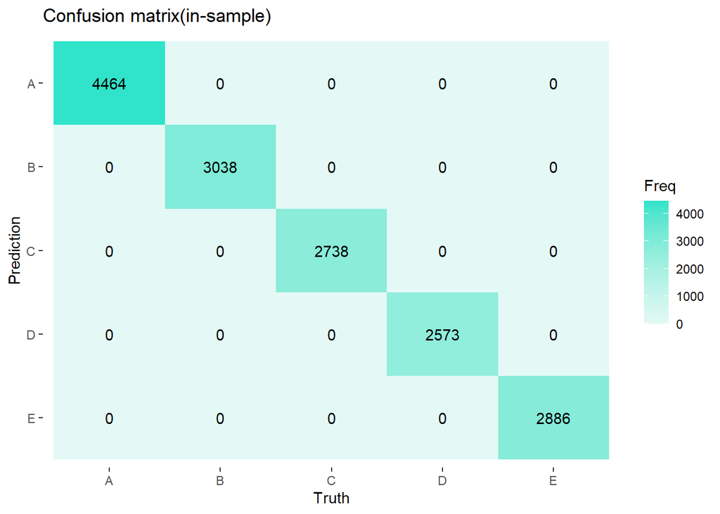

We get high accuracy.Checking out of sample error rate will help us determine whther our data is overfitting or not.

### Let us check out of sample error rate

```r
confusionMatrix(cvalidData$classe,predict(modFit,newdata = cvalidData))$overall
```

```
##       Accuracy          Kappa  AccuracyLower  AccuracyUpper   AccuracyNull
##      0.9964313      0.9954858      0.9940196      0.9980476      0.2849860
## AccuracyPValue  McnemarPValue
##      0.0000000            NaN
```

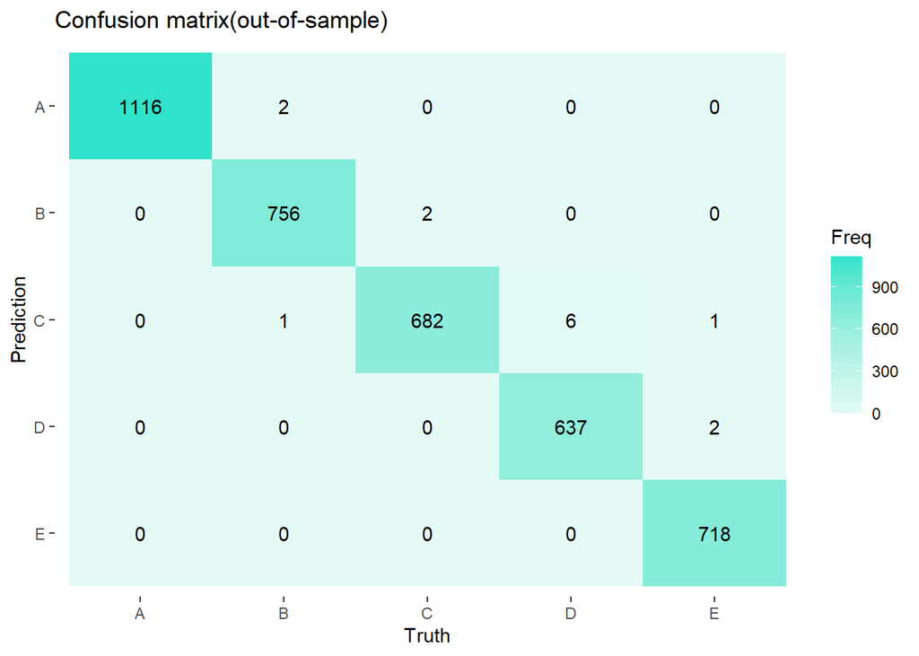

We get high accuracy for the test set also.So our model is fitting the data very good and **not overfitting** it

## Summary

We get a 100% accuracy on the train test and 99.64% accuracy on the cross validation set.The crossvalidation set was not used for training and hence can be used to determine out of sample error rate.

### Testing

```r
testing<- read.csv("pml-testing.csv")
testingClean <- testing[,colnames(trainingClean)[-53]]
predict(modFit,testingClean)
```

```
##  1  2  3  4  5  6  7  8  9 10 11 12 13 14 15 16 17 18 19 20
##  B  A  B  A  A  E  D  B  A  A  B  C  B  A  E  E  A  B  B  B
## Levels: A B C D E
```